# Uganda: SEAS5 drought forecast × humanitarian caseload

### The worst events on record, and what FloodScan saw

The four case studies below are the worst flood and landslide events in Uganda’s EM-DAT record, chosen to span the two regimes. For each: the FloodScan flood extent over the event window (left) with the districts named in the event record outlined, and the daily flood-extent series for the event’s region (right) with that year against every other year, and 2026 so far for context. The two wetland-extent events (2007 Teso, Dec 2019) are exactly the regime a record-wet OND forecast makes more likely; the two landslide events (Bududa 2010, Mt Elgon 2024) barely register in flood extent, which is the strongest visual argument for watching the Elgon and Rwenzori slopes with something other than FloodScan.

One live observation falls out of the green lines: **Eastern region’s 2026 flood extent has run near record levels all year even while Jun-Sep rainfall was the driest on record**. Flood extent there is following the system’s stored water (the Kyoga wetlands after three record flood seasons), not the current season’s rain, and that is the state the record-wet OND forecast will land on.

**EM-DAT case studies: maps + regional series**

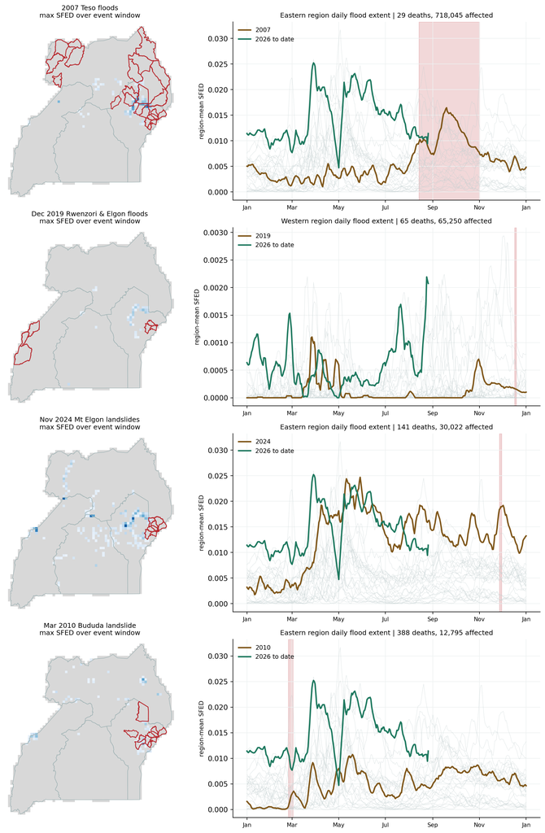

Left column: maximum FloodScan SFED over each event window (padded a week each side); red outlines are the districts named in EM-DAT. Right column: daily region-mean SFED (7-day rolling mean, the team’s convention) for the event’s region; gray = every other year, brown = the event year, green = 2026 to date, red band = the event window.

```python
ev_tif = stratus.load_blob_data(f"{UGA_DIR}/flood_events_maxsfed.tif", stage="dev")
ev_meta = stratus.load_parquet_from_blob(f"{UGA_DIR}/flood_events.parquet", stage="dev")
with MemoryFile(ev_tif) as mf, mf.open() as eds:
    ev_bands = {d: eds.read(i + 1) for i, d in enumerate(eds.descriptions)}
    ev_ext = [eds.bounds.left, eds.bounds.right, eds.bounds.bottom, eds.bounds.top]
    ev_in = geometry_mask(cod1.geometry, out_shape=eds.read(1).shape, transform=eds.transform, invert=True, all_touched=True)

fs1d = fs1.copy()
fs1d["doy"] = fs1d["valid_date"].dt.dayofyear
fs1d["yr"] = fs1d["valid_date"].dt.year

fig, axes = plt.subplots(len(ev_meta), 2, figsize=(11.5, 4.1 * len(ev_meta)),
                         gridspec_kw={"width_ratios": [1, 1.25]})
for i, ev in ev_meta.iterrows():
    axM, axT = axes[i]
    arr = ev_bands[ev["disno"]]
    m = np.ma.masked_where(~ev_in | (arr < 0.05), arr)
    axM.imshow(np.where(ev_in, 0, np.nan), extent=ev_ext, cmap="Greys", vmin=-1, vmax=3)
    imm = axM.imshow(m, extent=ev_ext, cmap="Blues", vmin=0, vmax=0.8, zorder=2)
    cod1.boundary.plot(ax=axM, color="#9db1b3", linewidth=0.6, zorder=3)
    evd = cod2[cod2["ADM2_EN"].isin(ev["districts"].split(";"))]
    evd.boundary.plot(ax=axM, color="#b8272d", linewidth=1.1, zorder=4)
    axM.set_xlim(29.4, 35.1); axM.set_ylim(-1.6, 4.4); axM.set_axis_off()
    axM.set_title(f"{ev['label']}\nmax SFED over event window", fontsize=9.5)

    reg = fs1d[fs1d["pcode"] == ev["region"]]
    pivd = reg.pivot_table(index="doy", columns="yr", values="mean").rolling(7, center=True, min_periods=1).mean()
    ev_yr = pd.Timestamp(ev["start"]).year
    for yr in pivd.columns:
        if yr not in (ev_yr, 2026):
            axT.plot(pivd.index, pivd[yr], color="#c4d0d1", lw=0.5, alpha=0.5)
    axT.plot(pivd.index, pivd[ev_yr], color="#7f5619", lw=2.0, label=str(ev_yr))
    if 2026 in pivd.columns:
        axT.plot(pivd.index, pivd[2026], color="#1e795f", lw=2.0, label="2026 to date")
    x0 = pd.Timestamp(ev["start"]).dayofyear; x1 = pd.Timestamp(ev["end"]).dayofyear
    axT.axvspan(x0 - 1, x1 + 1, color="#b8272d", alpha=0.18)
    axT.set_xticks([1, 60, 121, 182, 244, 305, 366],
                   ["Jan", "Mar", "May", "Jul", "Sep", "Nov", "Jan"], fontsize=8)
    axT.set_ylabel("region-mean SFED", fontsize=8.5)
    axT.legend(frameon=False, fontsize=8.5, loc="upper left")
    axT.grid(color="#eef1f1", zorder=0)
    axT.spines[["top", "right"]].set_visible(False)
    nm1 = {"UG1": "Central", "UG2": "Eastern", "UG3": "Northern", "UG4": "Western"}
    axT.set_title(f"{nm1[ev['region']]} region daily flood extent | "
                  f"{int(ev['deaths'])} deaths, {int(ev['affected']):,} affected", fontsize=9.5)
plt.tight_layout()
plt.show()
```

### Totals are not intensity: what a seasonal forecast can and cannot see

A seasonal forecast is a statement about three-month rainfall totals. Floods and landslides are triggered by rain at much shorter scales, so it is fair to ask how much the one says about the other. Two answers from the data:

- **Totals carry real but incomplete information about bursts.** Across the 112 region-seasons of the IMERG record (daily rain, 1998-2025), the OND total and the season’s largest 1-day and 3-day rains correlate at Spearman r = 0.70 and 0.73: about half the rank information is shared, and half is not. A wet season makes big bursts likelier; it does not schedule them.
- **Events split exactly along that line.** Taking every located EM-DAT event and asking how the two weeks before it ranked against the same calendar window in all other years: flood events sat under elevated 3-day bursts (median 73rd percentile, Wilcoxon p = 0.001, n = 36) *and* in elevated-total months (median 70th, p = 0.003). Landslide events sat under elevated bursts (median 79th, p = 0.019, n = 11) but their event-month totals were **not** significantly elevated (median 68th, p = 0.12).

One reconciliation, because these numbers can look contradictory. Three different links are in play. *Rain-to-rain*: wet seasons contain bigger bursts (r = 0.73 pooled; 0.59-0.75 within each region), the strongest link here. *Rain-to-events*: recorded flood events cluster in wet months (median 70th percentile, p = 0.003), so seasonal wetness does relate to the events people experience. *Rain-to-extent*: the season’s rainfall only weakly predicts total flooded area (r = 0.28), because area is dominated by what the wetland systems already hold, as 2025 showed. Rainfall predicts bursts and relates to impact events; it is specifically the year-to-year *extent* that runs on stored water.

Would monthly granularity help? Half of it would. Monthly totals are a better burst proxy than seasonal ones (monthly total vs that month’s largest 3-day rain: r = 0.82, against 0.73 for the season), and flooding inside OND is not uniform (November is the Central/Western climatological peak, and the 15 OND events in EM-DAT split Oct 4 / Nov 7 / Dec 4). But the forecast cannot deliver that granularity: SEAS5’s skill for individual OND months from the August issuance is r = 0.17-0.43 by region and month, mostly below the r >= 0.30 gate this document applies everywhere else, against 0.35-0.48 for the OND lump - the trimester average exists precisely to cancel the month-level noise. The one exception is November in the Northern and Eastern regions (r = 0.42-0.43), which happens to be the flood-peak month.

So the practical structure is a ladder of timescales. The trimester outlook says how wet the season is likely to be (extent-type flood risk, which tracks totals). The monthly climatology says when within the season flooding usually happens (November). Bursts and landslide timing belong to short-range rainfall monitoring (IMERG and weather-scale forecasts); no seasonal product reaches them. Watching the Elgon and Rwenzori slopes means the short end of that ladder, not seasonal totals.

**burst vs total analysis**

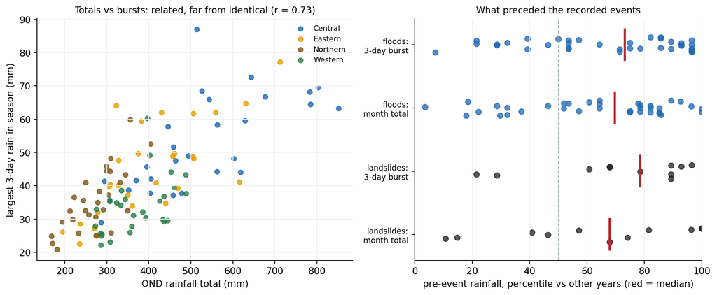

Left: each point is one region-season; the OND total against the season’s largest 3-day rain (IMERG, 1998-2025) - correlated (r = 0.73) but with wide spread at any given total. Right: rainfall conditions before each located EM-DAT event, as percentiles of the same calendar window in other years; flood events follow bursts and wet months, landslide events follow bursts only.

```python
imr = pd.read_sql("SELECT pcode, valid_date, mean FROM public.imerg WHERE iso3='UGA' AND adm_level=1",
                  engine, parse_dates=["valid_date"])
im0 = pd.read_sql("SELECT valid_date, mean FROM public.imerg WHERE iso3='UGA' AND adm_level=0",
                  engine, parse_dates=["valid_date"]).set_index("valid_date")["mean"].sort_index()
imr["yr"], imr["mo"] = imr["valid_date"].dt.year, imr["valid_date"].dt.month
iond = imr[imr["mo"].isin([10, 11, 12]) & (imr["yr"] < 2026)].sort_values("valid_date")
g = iond.groupby(["pcode", "yr"])
tot = g["mean"].sum()
mx3 = g["mean"].apply(lambda s: s.rolling(3).sum().max())

ev = emf.dropna(subset=["Start Year", "Start Month"]).copy()
ev["d"] = pd.to_datetime(dict(year=ev["Start Year"], month=ev["Start Month"], day=ev["Start Day"].fillna(15)))
def _burst_pct(d, win=14, agg=3):
    end = d + pd.Timedelta(days=2)
    obs = im0.loc[end - pd.Timedelta(days=win):end].rolling(agg).sum().max()
    hist = []
    for y in range(1998, 2026):
        try:
            e2 = end.replace(year=y)
        except ValueError:
            continue
        v = im0.loc[e2 - pd.Timedelta(days=win):e2].rolling(agg).sum().max()
        if not np.isnan(v):
            hist.append(v)
    return 100 * np.mean(np.array(hist) < obs)
im0m = im0.resample("MS").sum()
def _mo_pct(d):
    m = pd.Timestamp(d.year, d.month, 1)
    same = im0m[im0m.index.month == d.month]
    return 100 * np.mean(same.drop(index=m, errors="ignore") < im0m.get(m, np.nan))
ev["burst"] = ev["d"].map(_burst_pct)
ev["montot"] = ev["d"].map(_mo_pct)

fig, (axL, axR) = plt.subplots(1, 2, figsize=(11, 4.6), gridspec_kw={"width_ratios": [1.1, 1]})
RC = {"UG1": ("#1f69b3", "Central"), "UG2": ("#e69f00", "Eastern"), "UG3": ("#7f5619", "Northern"), "UG4": ("#2a7e43", "Western")}
for pc, (c, nm) in RC.items():
    axL.scatter(tot.loc[pc], mx3.loc[pc], s=26, color=c, alpha=0.8, label=nm)
axL.set_xlabel("OND rainfall total (mm)"); axL.set_ylabel("largest 3-day rain in season (mm)")
axL.legend(frameon=False, fontsize=8); axL.grid(color="#eef1f1", zorder=0)
axL.spines[["top", "right"]].set_visible(False)
axL.set_title("Totals vs bursts: related, far from identical (r = 0.73)", fontsize=10)

rows = [("Flood", "burst"), ("Flood", "montot"), ("Mass movement (wet)", "burst"), ("Mass movement (wet)", "montot")]
labels = ["floods:\n3-day burst", "floods:\nmonth total", "landslides:\n3-day burst", "landslides:\nmonth total"]
for k, ((typ, col), lab) in enumerate(zip(rows, labels)):
    yy = len(rows) - 1 - k
    vals = ev.loc[ev["Disaster Type"] == typ, col].dropna()
    axR.scatter(vals, np.full(len(vals), yy) + np.random.default_rng(7).uniform(-0.12, 0.12, len(vals)),
                s=34, color="#1f69b3" if typ == "Flood" else "#1f2324", alpha=0.75)
    axR.plot([vals.median()] * 2, [yy - 0.24, yy + 0.24], color="#b8272d", lw=2.4)
axR.set_yticks(range(len(rows)), labels[::-1], fontsize=8.5)
axR.axvline(50, color="#9db1b3", lw=1, ls="--")
axR.set_xlabel("pre-event rainfall, percentile vs other years (red = median)")
axR.set_xlim(0, 100); axR.grid(axis="x", color="#eef1f1", zorder=0)
axR.spines[["top", "right"]].set_visible(False)
axR.set_title("What preceded the recorded events", fontsize=10)
plt.tight_layout()
plt.show()
```

### Reading the 2026 flood season

What follows is interpretation built on the pieces above: an outlook, not a statistical result. Both levers point the same way this year. The ocean drivers are aligned: a strong El Niño *with* a positive IOD crossing its threshold in August and forecast positive through December, the 2015/2023 configuration, which is what the 91st-98th percentile wet OND forecast in the section above is expressing. And the landscape is measurably wet already: 2023, 2024 and 2025 are the three largest flood ONDs of the FloodScan record (1998-2025), and 2026’s January-August standing flood extent ranks among the top three of all 29 years in every region (Central 1st, Eastern and Western 2nd, Northern 3rd). Neither guarantees a flood year: the driver-to-rain step is statistically solid, the rain-to-flood step is only categorically supported, and year-to-year persistence is suggestive at best. But the historically informative conditions are simultaneously present.

## Method notes & caveats

- Forecast selection is the app’s rule verbatim (code imported from `pipeline/export_static_site.py`). Skill and return periods come from the repo’s `src.skill.run_all_combinations`, detrended variant, identical to the Forecast × HNRP tab.
- The district climate stats are new. Uganda sits outside the rasterstats DB’s adm2 coverage, so SEAS5/ERA5 zonal statistics over the 135 CODAB districts were computed with exactextract from the same COGs (`pipeline/compute_uga_district_stats.py`), then `pipeline/compute_skill_uga_adm2.py` ran the standard skill code. Region-level exactextract means reproduce the DB’s stored means within about 1%.
- JIAF 2.0 Light covers 22 districts (× host/refugee groups; the raw sheets’ 26 distinct “District” values include four subtotal rows); all other districts appear on the map for climate context only. Joint PiN is the mosaic-rule maximum of sectoral PiN, not their sum. Severity classifies areas, not people.
- Targeted/reached levels are independent rollups in the source workbooks (the region series does not equal the sum of its districts); this document only ever uses one level at a time.
- The empirical return period saturates at 46 years (record length + 1). A district shown at 46 is “drier than anything since 1981”, not “exactly a 46-year event”. Use the deficit (% of normal) to compare districts once the cap binds.
- Flood layers: FloodScan daily SFED (0.083 deg) seasonal maxima per OND; flooded = SFED >= 0.05 (the noise floor used by ds-floodexposure-monitoring); return periods are rank-based empirical ((n+1)/rank), same convention as the drought side. Climate indices are OND means of NOAA PSL’s DMI (HadISST) and ONI series, stored at `raw/climate_indices/` for reproducibility. EM-DAT events are located by matching district names in the Location text (42 of 47 matched); flood and wet mass-movement (landslide) events are analyzed as separate types. EM-DAT under-records slow wetland inundation, records no impact where flooding meets no people, and its reporting density grows over time, so event counts are a geography of recorded impacts, not a hazard climatology.
- Intensity analysis: IMERG daily rainfall from public.imerg (adm0/adm1, 1998-2025); pre-event windows are the 14 days ending two days after the EM-DAT start date, compared against the same calendar window in all other years; monthly EM-DAT start dates without a day use the 15th.
- Terego (created 2020) is not in the CODAB vintage: its rows keep their own people figures but inherit UG3072 (Arua)’s forecast; “Madi-Okollo & Terego” inherits UG3084 (Madi Okollo).